# Лабораторная работа № 7

## Права на выполнение

Определим опции команды chmod, необходимые для того, чтобы присвоить файлам (australia, play, my_os, feathers) выделенные права доступа, также создадим нужные файлы (рис. 28, рис. 29).

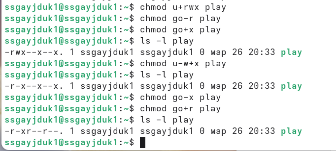

Figure 28: image28

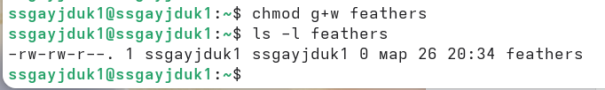

Figure 29: image29

## Просмотр файлов

Просмотрим содержимое файла /etc/password (рис. 30).

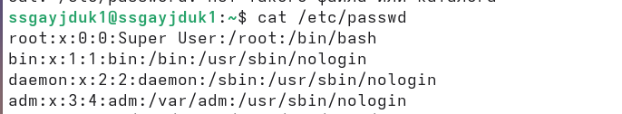

Figure 30: image30

## Копирование файлов

Скопируем файл ~/feathers в файл ~/file.old (рис. 31).

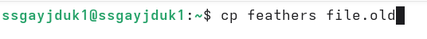

Figure 31: image31

Лишим владельца файла ~/feathers права на чтение (рис. 35).

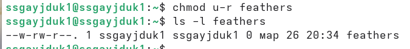

Figure 35: image35

Попытаемся просмотреть файл ~/feathers командой cat. Будет отказано в доступе (рис. 36).

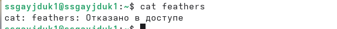

Figure 36: image36

Попытаемся скопировать файл ~/feathers. Также будет отказано в доступе (рис. 37).

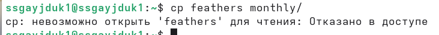

Figure 37: image37

Дадим владельцу файла ~/feathers право на чтение (рис. 38).

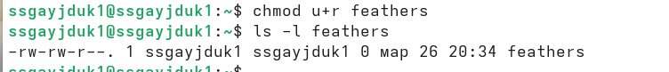

Figure 38: image38

## Права на выполнение

Лишим владельца каталога ~/play права на выполнение (рис. 39).

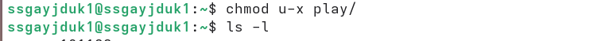

Figure 39: image39

Перейдем каталог ~/play. Будет отказано в доступе (рис. 40).

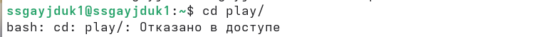

Figure 40: image40

## man

Прочитаем man по командам mount, fsck, mkfs, kill (рис. 42).

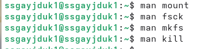

Figure 42: image42

## Выводы

Ознакомились с файловой системой Linux, её структурой, именами и содержанием каталогов. Приобрели практические навыки по применению команд для работы с файлами и каталогами, по управлению процессами (и работами), по проверке использования диска и обслуживанию файловой системы.

## Список литературы

1.Kulyabov. Лабораторная работа № 7. Анализ файловой структуры UNIX. Команды для работы с файлами и каталогами. RUDN